# Assignment 1 - Time Series Analysis

Siddhi Potdar - s3856360

## Predicting the closing price of a share in ASX for the next 5 days based on it’s data for 144 days.

## Table of Contents

1. Intruduction

2. Load the data set

—2.1 Creating an object and plotting the time series graph

3. Linear Model

—3.1 The fitted linear model graph

—3.2 Residuals

—3.3 Time series plot of residuals

—3.4 Histogram

—3.5 Q-Q plot

—3.6 ACF plot

—3.7 Shapiro-Wilk test

4. Quadratic Model

—4.1 The fitted quadratic model graph

—4.2 Residuals

—4.3 Time series plot of residuals

—4.4 Histogram

—4.5 Q-Q plot

—4.6 ACF plot

—4.7 Shapiro-Wilk test

5. Cyclical or seasonal model

—5.2 Residuals

—5.3 Time series plot of residuals

—5.4 Histogram

—5.5 Q-Q plot

—5.6 ACF plot

—5.7 Shapiro-Wilk test

6. Cosine Model

—6.1 The fitted cosine model graph

—6.2 Residuals

—6.3 Time series plot of residuals

—6.4 Histogram

—6.5 Q-Q plot

—6.6 ACF plot

—6.7 Shapiro-Wilk test

7. Comparison

8. Forecasting

9. Conclusion

10. References

## Introduction

The closing price of a share in ASX is provided. The data set `assignment1Data2022.csv` is consisted of 144 observations out of 252 trading days in a year. The data set comprises of two columns, days and closing price of a share for that day respectively. In this assignment, the changes has been observed in the closing price with the use of time series plots. By implementing the model building strategy, I chose the best fitted model among the 4 models. The aim is to predict the closing price of a share for the next 5 days using the best model.

```r
#To load desired packages.

library(TSA)
library(readr)
```

## Load the data set

This chunk will load the data set and print the first 6 values. I also displayed the structure of the data set.

```r
#Load the data into price variable
price<-read.csv("assignment1Data2022.csv")

#Print first 6 values and the structure of the data set
head(price)
```

```
##   X  x
## 1 1 80
## 2 2 80
## 3 3 80
## 4 4 80
## 5 5 80
## 6 6 80
```

```r
str(price)
```

```
## 'data.frame':    144 obs. of  2 variables:
##  $ X: int  1 2 3 4 5 6 7 8 9 10 ...
##  $ x: num  80 80 80 80 80 ...
```

## Creating an object and plotting the time series graph

```r
#To create an object of the column and store itin the variable 'price_obj'
price_obj<-ts(price$x)

#To convert it into time series objects and plot the graph

time(price_obj)
```

```
## Time Series:
## Start = 1
## End = 144
## Frequency = 1
##   [1]   1   2   3   4   5   6   7   8   9  10  11  12  13  14  15  16  17  18
##  [19]  19  20  21  22  23  24  25  26  27  28  29  30  31  32  33  34  35  36
##  [37]  37  38  39  40  41  42  43  44  45  46  47  48  49  50  51  52  53  54
##  [55]  55  56  57  58  59  60  61  62  63  64  65  66  67  68  69  70  71  72
##  [73]  73  74  75  76  77  78  79  80  81  82  83  84  85  86  87  88  89  90
##  [91]  91  92  93  94  95  96  97  98  99 100 101 102 103 104 105 106 107 108
## [109] 109 110 111 112 113 114 115 116 117 118 119 120 121 122 123 124 125 126
## [127] 127 128 129 130 131 132 133 134 135 136 137 138 139 140 141 142 143 144
```

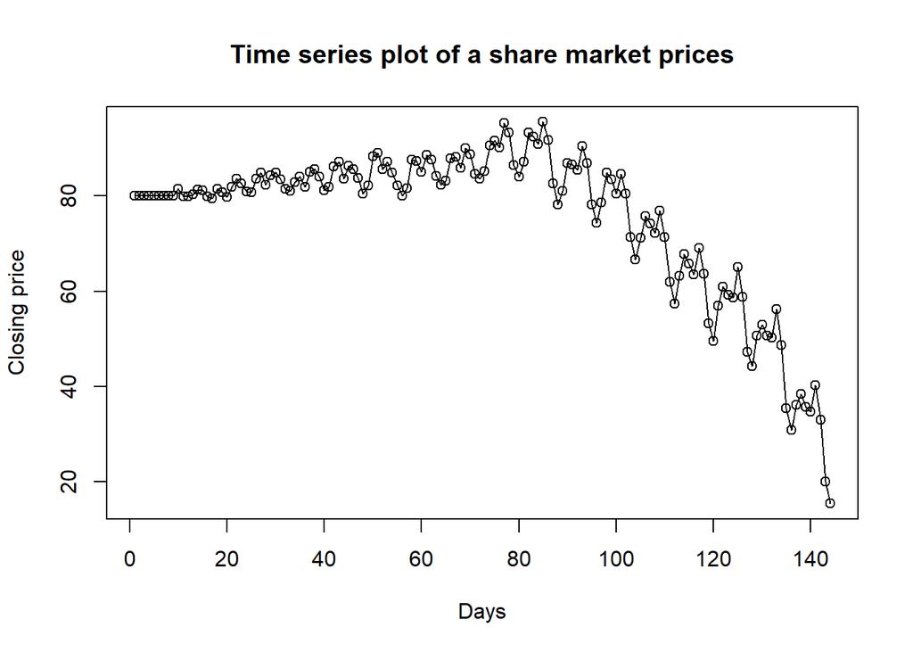

```r
plot(price_obj,type='o',xlab="Days",ylab="Closing price",main="Time series plot of a share market prices")
```

It is observed that the data is not stationary. I also assume that the null hypothesis states that the graph is normally distributed. This hypothesis is used later in the models.

## Linear model

```r
#To store the time series object and fitting the series into linear model.
ts_var<-time(price_obj)
linear_model<-lm(price_obj~ts_var)
summary(linear_model)
```

```
##
## Call:
## lm(formula = price_obj ~ ts_var)
##
## Residuals:
##     Min      1Q  Median      3Q     Max
## -41.083  -8.949   0.231   8.896  23.370
##
## Coefficients:
##             Estimate Std. Error t value Pr(>|t|)
## (Intercept) 94.53267    2.02418   46.70   <2e-16 ***
## ts_var      -0.26377    0.02422  -10.89   <2e-16 ***
## ---
## Signif. codes:  0 '***' 0.001 '**' 0.01 '*' 0.05 '.' 0.1 ' ' 1
##
## Residual standard error: 12.08 on 142 degrees of freedom
## Multiple R-squared:  0.4551, Adjusted R-squared:  0.4513
## F-statistic: 118.6 on 1 and 142 DF,  p-value: < 2.2e-16
```

I observed that the estimates of the intercept and slope are β^0= 94.53 and β^1= -0.26 respectively. The slope is also statistically significant at 5% significance level as the p-value is less than 0.05.

### The fitted linear model graph

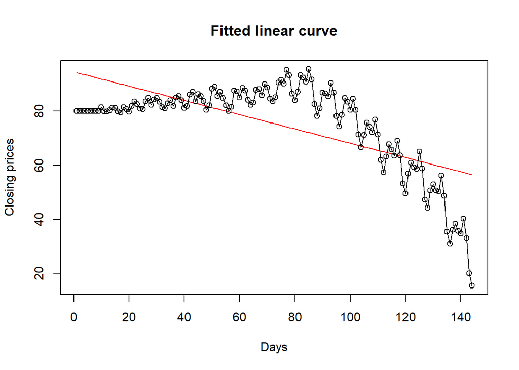

```r
#To plot fitted linear model

plot(ts(fitted(linear_model)), ylim = c(min(c(fitted(linear_model),
     as.vector(price_obj))), max(c(fitted(linear_model),as.vector(price_obj)))),ylab='Closing prices' ,xlab='Days',
     main = "Fitted linear curve",col="red")

#To add the fittest least square least line.
lines(as.vector(price_obj),type="o")
```

### Residuals for linear model

If the model is reasonably correct the the residuals should behave like true stochastic component. Similarly, if the stochastic component is a white noise then the residuals should behave like independent random variables with zero standard deviation and mean.

```r
#The residuals for linear model
reslm=rstudent(linear_model)
```

### Time series plot of residuals

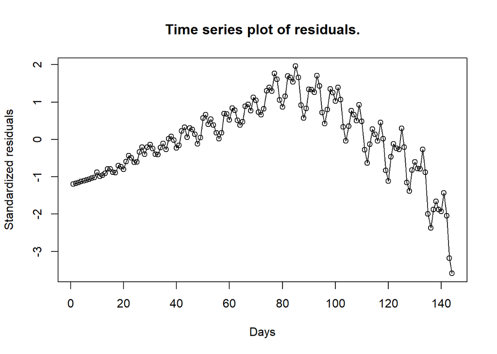

```r
plot(y=reslm,x=as.vector(time(price_obj)), xlab='Days',ylab='Standardized residuals',type='o', main = "Time series plot of residuals.")
```

### Histogram linear model

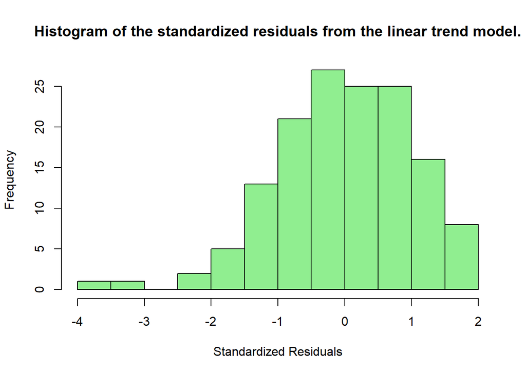

```r
#To plot histogram
hist(reslm,xlab='Standardized Residuals',col='lightgreen', main = "Histogram of the standardized residuals from the linear trend model.")
```

The histogram can be used to check the normality of the residuals. The plot is left skewed as deviation can be observed on the left ends and the peak is inclined towards the right end.

### Q-Q plot linear model

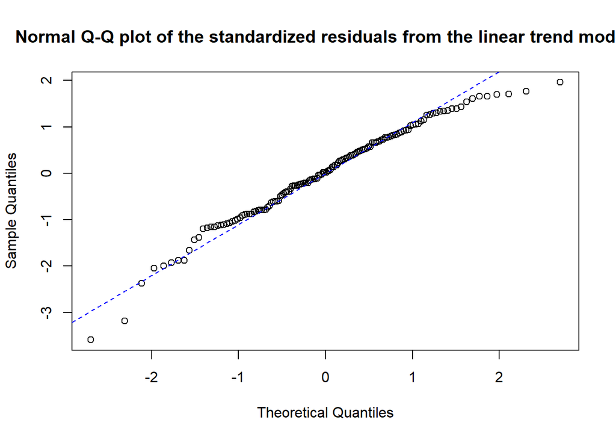

```r
# To plot the Q-Q plot
qqnorm(reslm, main = "Normal Q-Q plot of the standardized residuals from the linear trend model.")
qqline(reslm, col = 'blue', lwd = 1, lty = 2)
```

It is observed that both the tails are deviated from the straight line. Therefore, it is not normally distributed.

### ACF Plot linear model

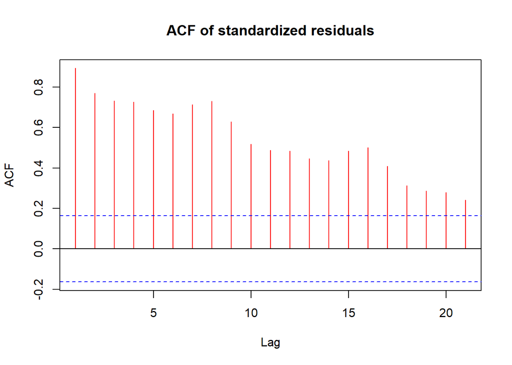

```r
# To plot the ACF linear model.
acf(reslm,col='red', main = "ACF of standardized residuals")
```

All the values are above the horizontal dashed lines. Hence, I decide that the stochastic component of the series is not a white noise.

### Shapiro-Wilk test

```r
#The Shapiro-Wilk test

shapiro.test(reslm)
```

```
##
##  Shapiro-Wilk normality test
##
## data:  reslm
## W = 0.97653, p-value = 0.01413
```

The p-value is 0.01413 which is less than 0.05 so we reject the null hypothesis that the stochastic component is normally distributed.

## Quadratic model

```r
ts_var=time(price_obj)
ts_var2 = ts_var^2
quad_model = lm(price_obj~ts_var+ts_var2)
summary(quad_model)
```

```
##
## Call:
## lm(formula = price_obj ~ ts_var + ts_var2)
##
## Residuals:
##      Min       1Q   Median       3Q      Max
## -17.8176  -3.5322  -0.7553   3.6988  12.5656
##
## Coefficients:
##               Estimate Std. Error t value Pr(>|t|)
## (Intercept) 70.2777995  1.4284180   49.20   <2e-16 ***
## ts_var       0.7330056  0.0454811   16.12   <2e-16 ***
## ts_var2     -0.0068743  0.0003038  -22.62   <2e-16 ***
## ---
## Signif. codes:  0 '***' 0.001 '**' 0.01 '*' 0.05 '.' 0.1 ' ' 1
##
## Residual standard error: 5.634 on 141 degrees of freedom
## Multiple R-squared:  0.8823, Adjusted R-squared:  0.8807
## F-statistic: 528.6 on 2 and 141 DF,  p-value: < 2.2e-16
```

I observed that the estimates of the intercept are β^0= 70.28 respectively. The slope is also statistically significant at 5% significance level as the p-value is less than 0.05.

### Fitted quadratic model

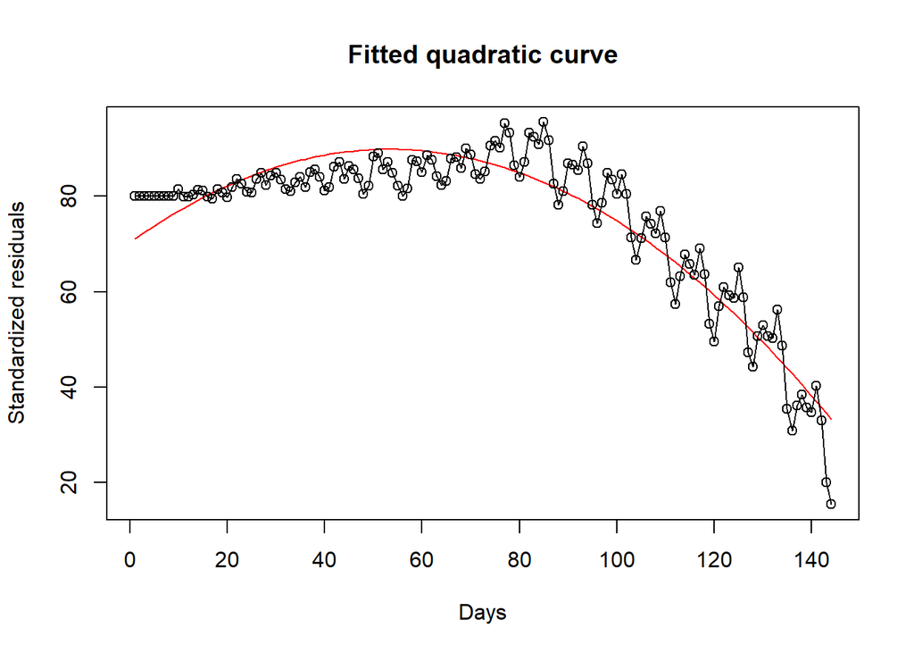

```r
#To plot fitted quadratic model
plot(ts(fitted(quad_model)), ylim = c(min(c(fitted(quad_model),
     as.vector(price_obj))), max(c(fitted(quad_model),as.vector(price_obj)))),ylab='Standardized residuals' ,xlab='Days',
     main = "Fitted quadratic curve",col="red")
lines(as.vector(price_obj),type="o")
```

### Residuals

```r
#To carry out the residuals
resquad=rstudent(quad_model)
```

### Time series analysis plot of residuals

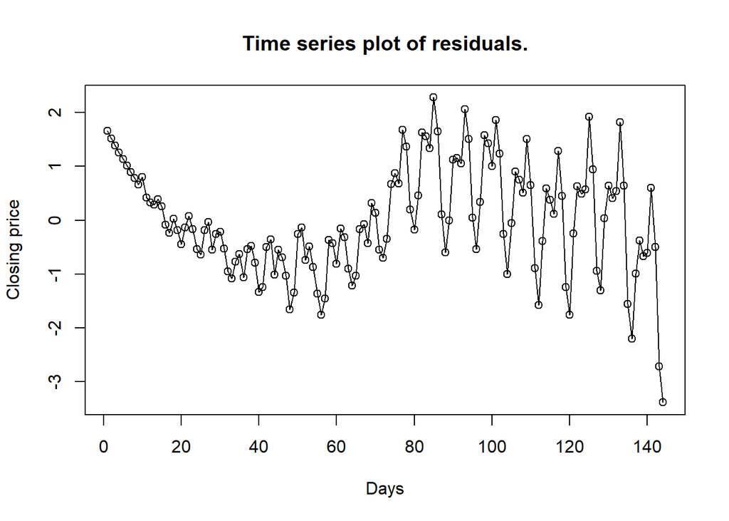

```r
plot(y=resquad,x=as.vector(time(price_obj)), xlab='Days',ylab='Closing price',type='o', main = "Time series plot of residuals.")
```

### Histogram quadratic model

[figure not shown]

```r
#To plot histogram
hist(resquad,xlab='Standardized Residuals',col='lightgreen', main = "Histogram of the standardized residuals from the seasonal means model.")
```

The graph is slightly left skewed as a slight deviation is observed at the left tail. Therefore, the graph is somewhat normally distributed.

### Q-Q plot quadratic model

[figure not shown]

```r
#To plot Q-Q plot for quadratic model.

qqnorm(resquad, main = "Normal Q-Q plot of the standardized residuals from the seasonal means model.")
qqline(resquad, col = 'blue', lwd = 1, lty = 2)
```

It is observed that the bottom tail is deviated from the straight line. But, all the values in the center are lying exactly on the straight line. Therefore, it is somewhat normally distributed.

### ACF Plot quadratic model

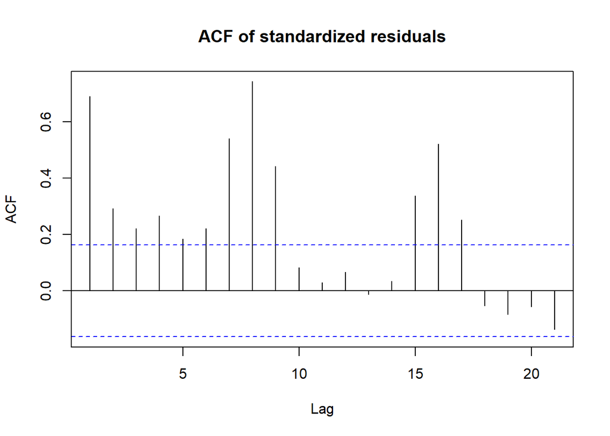

```r
#To plot ACF plot for quadratic model

acf(resquad, main = "ACF of standardized residuals")
```

### Shapiro-Wilk test

```r
#Shapiro-Wilk test

shapiro.test(resquad)
```

```
##
##  Shapiro-Wilk normality test
##
## data:  resquad
## W = 0.98771, p-value = 0.2324
```

The p-value is 0.2324 which is greater than 0.05 so we accept the null hypothesis that the stochastic component is normally distributed.

## Cyclical or seasonal model

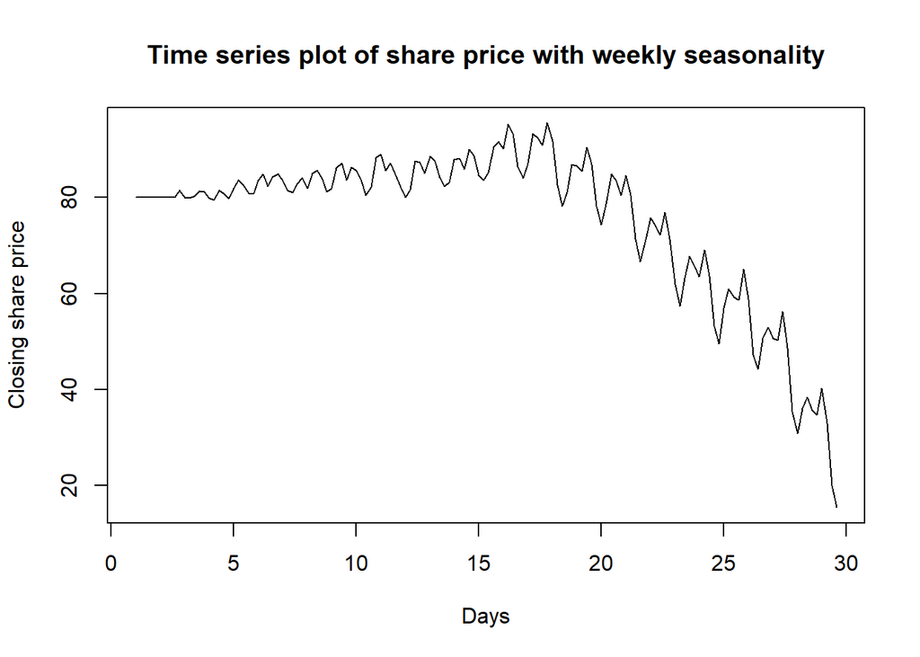

```r
cyc_ts <- ts(price$x, frequency = 5)
plot(cyc_ts, ylab = 'Closing share price', xlab = 'Days',
     main = 'Time series plot of share price with weekly seasonality')
```

```r
freq. = season(cyc_ts)
cyc_model = lm(cyc_ts ~ freq.-1)
summary(cyc_model)
```

```
##
## Call:
## lm(formula = cyc_ts ~ freq. - 1)
##
## Residuals:
##     Min      1Q  Median      3Q     Max
## -58.912  -4.710   5.935   9.830  19.643
##
## Coefficients:
##               Estimate Std. Error t value Pr(>|t|)
## freq.Season-1   75.883      3.070   24.72   <2e-16 ***
## freq.Season-2   75.671      3.070   24.65   <2e-16 ***
## freq.Season-3   75.100      3.070   24.46   <2e-16 ***
## freq.Season-4   74.379      3.070   24.23   <2e-16 ***
## freq.Season-5   76.035      3.124   24.34   <2e-16 ***
## ---
## Signif. codes:  0 '***' 0.001 '**' 0.01 '*' 0.05 '.' 0.1 ' ' 1
##
## Residual standard error: 16.53 on 139 degrees of freedom
## Multiple R-squared:  0.9557, Adjusted R-squared:  0.9541
## F-statistic: 599.3 on 5 and 139 DF,  p-value: < 2.2e-16
```

```r
cyc_model_1=lm(cyc_ts~freq.) # remove -1 to include the intercept term in the model
summary(cyc_model_1)
```

```
##
## Call:
## lm(formula = cyc_ts ~ freq.)
##
## Residuals:
##     Min      1Q  Median      3Q     Max
## -58.912  -4.710   5.935   9.830  19.643
##
## Coefficients:
##               Estimate Std. Error t value Pr(>|t|)
## (Intercept)    75.8830     3.0698  24.719   <2e-16 ***
## freq.Season-2  -0.2118     4.3413  -0.049    0.961
## freq.Season-3  -0.7827     4.3413  -0.180    0.857
## freq.Season-4  -1.5042     4.3413  -0.346    0.730
## freq.Season-5   0.1520     4.3799   0.035    0.972
## ---
## Signif. codes:  0 '***' 0.001 '**' 0.01 '*' 0.05 '.' 0.1 ' ' 1
##
## Residual standard error: 16.53 on 139 degrees of freedom
## Multiple R-squared:  0.001394,   Adjusted R-squared:  -0.02734
## F-statistic: 0.0485 on 4 and 139 DF,  p-value: 0.9955
```

As the R-squared value for the above intercept is -0.02734, we will not consider the model. I considered the above model which gave R-squared value as 0.9541.

### Residual Analysis

```r
cyc_model = rstudent(cyc_model)
```

### Time series plot

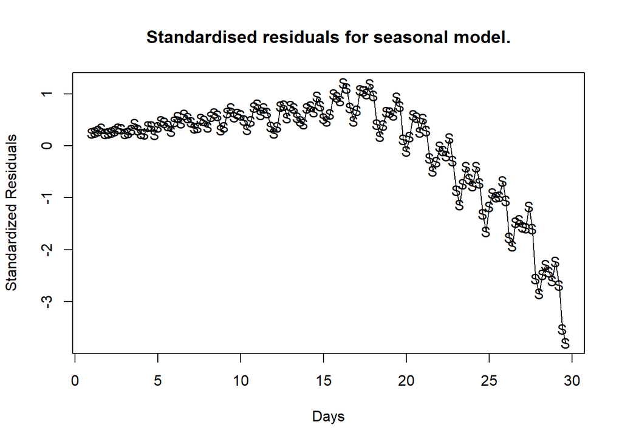

```r
plot(y = cyc_model, x = as.vector(time(cyc_ts)),xlab = 'Days', ylab='Standardized Residuals',type='l',main = "Standardised residuals for seasonal model.")
points(y=cyc_model,x=time(cyc_ts), pch=as.vector(season(cyc_ts)))
```

### Histogram cyclical model

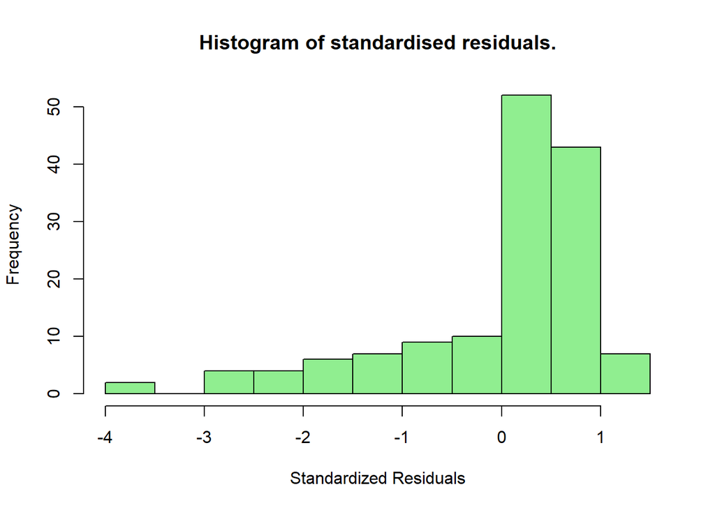

```r
hist(cyc_model,xlab='Standardized Residuals',col="lightgreen", main = "Histogram of standardised residuals.")
```

The graph is left skewed as a deviation is observed at the left tail. Also, the peak is inclined towards the right. Therefore, the graph is not normally distributed.

### Q-Q plot for cyclical or seasonal model

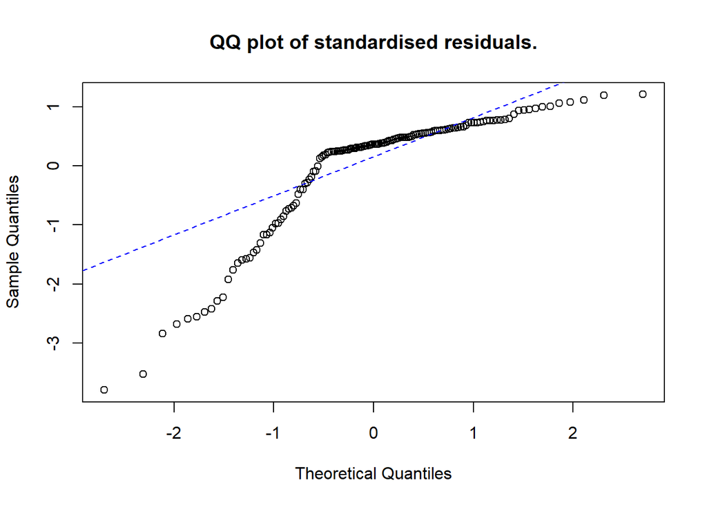

```r
qqnorm(y=cyc_model, main = "QQ plot of standardised residuals.")
qqline(y=cyc_model, col = 'blue', lwd = 1, lty = 2)
```

It is observed that the values on the both the tails are deviating from the straight line. Hence, the graph is not normally distributed.

### ACF for cyclical model

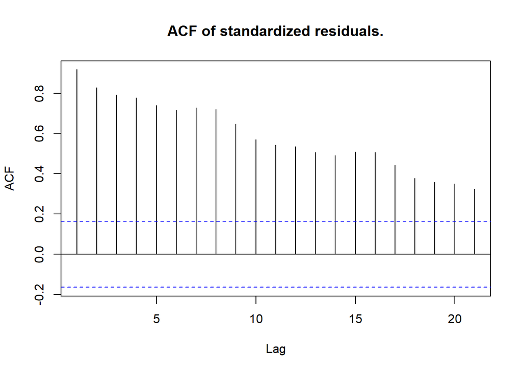

```r
acf(cyc_model, main = "ACF of standardized residuals.")
```

All the values are above the horizontal dashed lines. Hence, I decide that the stochastic component of the series is not a white noise.

### Shapiro-wilk test

```r
shapiro.test(cyc_model)
```

```
##
##  Shapiro-Wilk normality test
##
## data:  cyc_model
## W = 0.79649, p-value = 7.213e-13
```

The p-value is 7.213e-13 which is less than 0.05 so we reject the null hypothesis that the stochastic component is normally distributed.

## Cosine model

```r
har.=harmonic(price_obj,0.45) # calculate cos(2*pi*t) and sin(2*pi*t)
cosine_model=lm(price_obj~har.)
summary(cosine_model)
```

```
##
## Call:
## lm(formula = price_obj ~ har.)
##
## Residuals:
##     Min      1Q  Median      3Q     Max
## -57.706  -1.121   4.431   9.980  23.634
##
## Coefficients: (1 not defined because of singularities)
##                  Estimate Std. Error t value Pr(>|t|)
## (Intercept)     7.777e+01  1.632e+00  47.643   <2e-16 ***
## har.cos(2*pi*t)        NA         NA      NA       NA
## har.sin(2*pi*t) 1.303e+14  5.191e+13   2.509   0.0132 *
## ---
## Signif. codes:  0 '***' 0.001 '**' 0.01 '*' 0.05 '.' 0.1 ' ' 1
##
## Residual standard error: 16.02 on 142 degrees of freedom
## Multiple R-squared:  0.04247,    Adjusted R-squared:  0.03572
## F-statistic: 6.297 on 1 and 142 DF,  p-value: 0.01321
```

I observed that the estimates of the intercept are β^0= 7.777e+01. The slope is also statistically significant at 5% significance level as the p-value is less than 0.05.

### Fitted cosine model

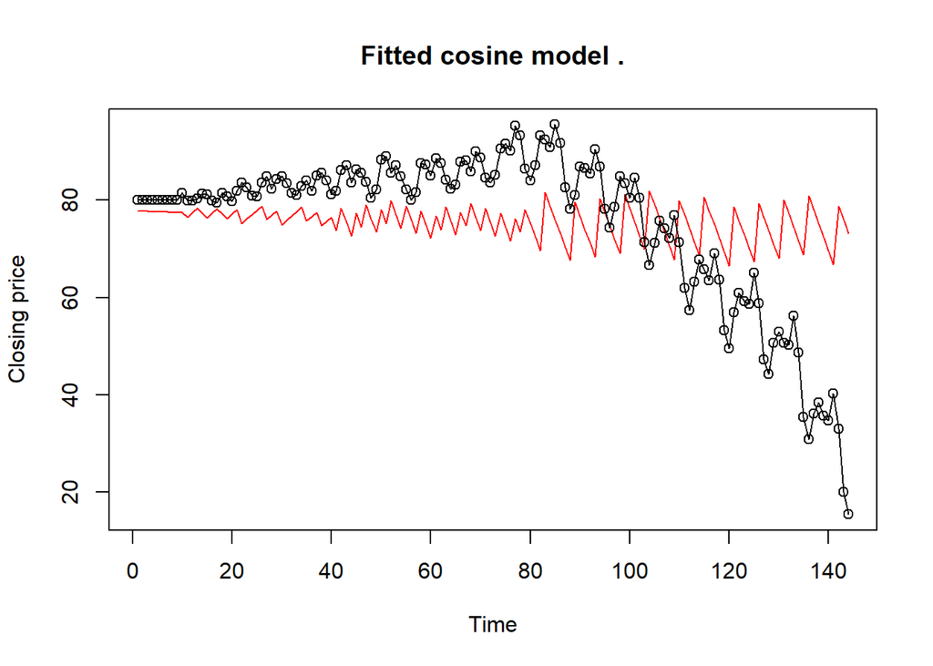

```r
#To plot the fitted cosine model

plot(ts(fitted(cosine_model)),ylab='Closing price',type='l',
ylim=range(c(fitted(cosine_model),price_obj)),col='red',main="Fitted cosine model .")
lines(as.vector(price_obj),type='o')
points(price_obj)
```

### Residuals

```r
#To carry out the residuals
rescos=rstudent(cosine_model)
```

### Time series analysis for residuals -cosine model

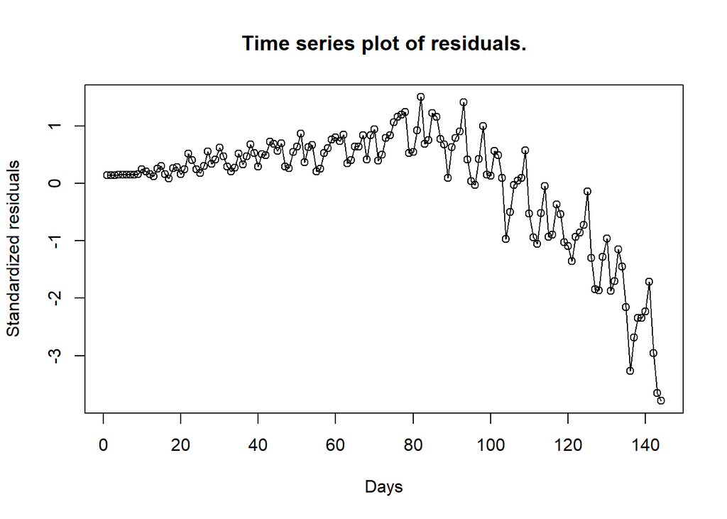

```r
#To plot the time series plot for the residuals
plot(y=rescos,x=as.vector(time(price_obj)), xlab='Days',ylab='Standardized residuals',type='o', main = "Time series plot of residuals.")
```

### Histogram cosine model

[figure not shown]

```r
#To plot the histogram
hist(rescos,xlab='Standardized Residuals',col='lightgreen', main = "Histogram of the standardized residuals from the seasonal means model.")
```

The graph is left skewed as a deviation is observed at the left tail. Also, the peak is inclined towards the right. Therefore, the graph is not normally distributed.

### Q-Q plot for cosine model

[figure not shown]

```r
#To plot the Q-Q plot for cosine model.


qqnorm(rescos, main = "Normal Q-Q plot of the standardized residuals from the seasonal means model.")
qqline(rescos, col = 2, lwd = 1, lty = 2)
```

It is observed that the values on the bottom tail are deviating from the straight line. Hence, the graph is not normally distributed.

### ACF Plot-Cosine model

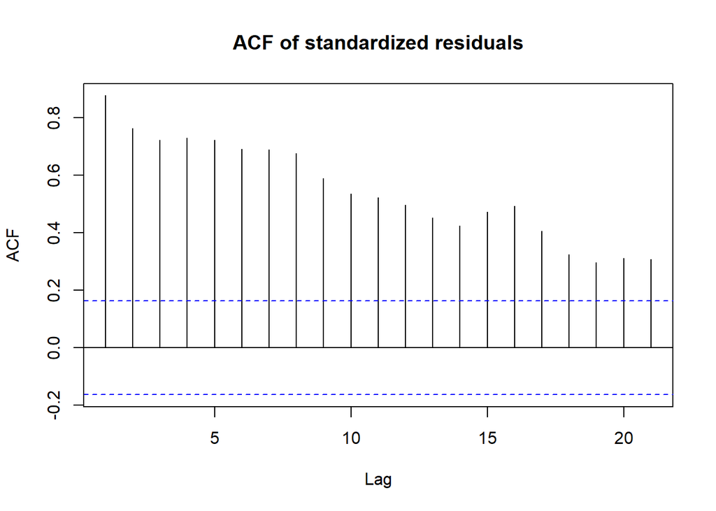

```r
acf(rescos, main = "ACF of standardized residuals")
```

All the values are above the horizontal dashed lines. Hence, I decide that the stochastic component of the series is not a white noise.

### Shapiro-Wilk test

```r
#Shapiro-Wilk test

shapiro.test(rescos)
```

```
##
##  Shapiro-Wilk normality test
##
## data:  rescos
## W = 0.82711, p-value = 9.656e-12
```

The p-value is 9.656e-12 which is less than 0.05 so we reject the null hypothesis that the stochastic component is normally distributed.

## Comparison

For predicting the closing price of a share for the next 5 days, I compared the results obtained from the above models.

### Linear Model

- R-squared: 0.4513
- ACF - the stochastic component of the series is not a white noise
- Shapiro-Wilk p-value = 0.01413

### Cosine trend Model

- R-squared: 0.03572
- ACF - the stochastic component of the series is not a white noise
- Shapiro-Wilk p-value = 9.656e-12

### Cyclical or seasonal model

- R-squared: 0.9541
- ACF - the stochastic component of the series is not a white noise
- Shapiro-Wilk p-value = 7.213e-13

### Quadratic Model

As per the results obtained from the above models, Linear and Cosine models are not the good fit. Quadratic model cannot be said as the best fit as the R-squared value is greater than 0.85 but when compared to the other models, Quadratic model is the best fitted model. This best fitted model is used later for the forecasting.

## Forecasting

```r
#Predicting the values for the next 5 days
h = 5 #Next 5 observations
ts_var <- time(price_obj)
ts_var2 <- ts_var^2
nextDays <- data.frame(ts_var = seq(145, 144+h, 1),
                         ts_var2 = seq(145, 144+h, 1)^2)
forecastingModel <- predict(quad_model, nextDays, interval = "prediction")
print(forecastingModel)
```

```
##        fit      lwr      upr
## 1 32.03113 20.53974 43.52253
## 2 30.76371 19.25266 42.27477
## 3 29.48255 17.95092 41.01417
## 4 28.18763 16.63449 39.74077
## 5 26.87896 15.30335 38.45458
```

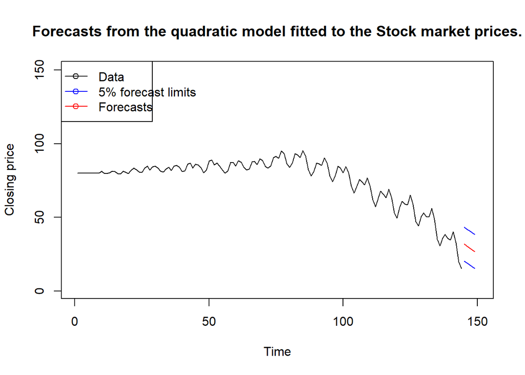

```r
#To plot the graph for the prediction.
plot(price_obj, xlim= c(1,144+h+1), ylim = c(1,150),
     ylab = "Closing price",
     main = "Forecasts from the quadratic model fitted to the Stock market prices.")
lines(ts(as.vector(forecastingModel[,3]), start = 145), col="blue", type="l")
lines(ts(as.vector(forecastingModel[,1]), start = 145), col="red", type="l")
lines(ts(as.vector(forecastingModel[,2]), start = 145), col="blue", type="l")
legend("topleft", lty=1, pch=1, col=c("black","blue","red"),text.width = 18,c("Data","5% forecast limits","Forecasts"))
```

After the prediction, the values for the next 5 days is as follows,

```
    Days   | Closing Price
~~~~~~~~~~~~~~~~~~~~~~~~~~~
 145th day |   32.03113
 146th day |   30.76371
 147th day |   29.48255
 148th day |   28.18763
 149th day |   26.87896
```

## Conclusion

The closing price of a share showed the downward trend. The linear, quadratic, cyclic or seasonal model and cosine model was performed. As per the results obtained,I cannot say that the quadratic model was considered as the best fitted model as the R-squared value is greater than 0.85, but if compared with all the models, it is the good fit. I later used quadratic model for forecasting and predicted the closing prices of a share market for the next 5 days.

## References

Dr Haydar Demirhan 2022, Module 1: Basic Plots, Examples, and Fundamental Concepts, lecture notes, MATH 1318 Time Series Analysis, RMIT University, viewed 26/03/2022

Dr Haydar Demirhan 2022, Module 2: Analysis of Trends, lecture notes, MATH 1318 Time Series Analysis, RMIT University, viewed 26/03/2022